# Generalised additive mixed models

Random smooths, autocorrelation and non-linear interactions

Dr Massimiliano Canzi

# Generalised additive mixed models

`Did you know:` Egyptian fruit bats live in colonies of hundreds to thousands of individuals, can live for at least 25 years in captivity, and are extremely vocal in their social interactions.

*Source: Prat, Taub & Yovel (2015), Science Advances*

## Where we are

Lecture 2: smooth terms, difference smooths and significance testing with GAMs, in models that treated every measurement as independent. Today: the “mixed” part, following the second half of Sóskuthy’s (2018) workshop.

## Today

1. Dependencies in curve data
2. Random effects in GAMMs
3. Autocorrelation
4. Non-linear interactions
5. Checking and reporting

## The data

The PRICE trajectories from lecture 2 (`price_f2` from {simling}), now with an ordered factor for L1.

```r
price <- price_f2 |>
  mutate(l1_o = as.ordered(l1), .after = l1)
contrasts(price$l1_o) <- "contr.treatment"
```

## Speakers and tokens

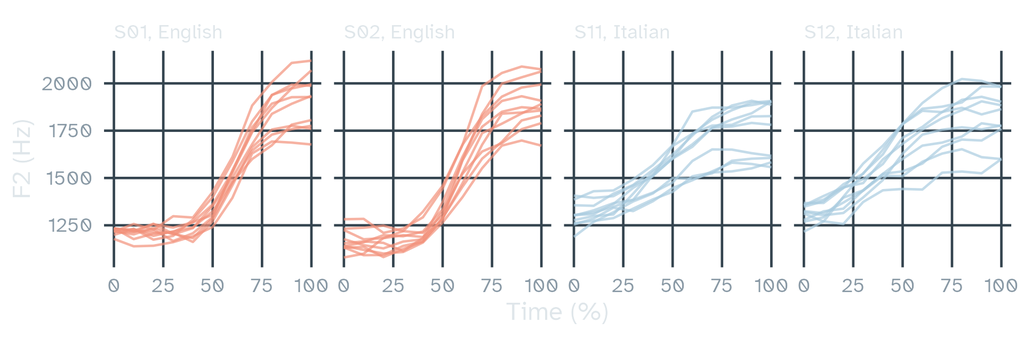

Ten tokens from each of four speakers. Each speaker’s tokens sit at their own height, and within a token, neighbouring measurements move up and down together.

# Dependencies

`Did you know:` Prat and colleagues recorded 22 Egyptian fruit bats for 75 days. Their calls carried information about the caller, the context and even the addressee: the bat the call was directed at.

*Source: Prat, Taub & Yovel (2016), Scientific Reports*

## Four kinds of model

|  | Fixed effects only | With random effects |
| --- | --- | --- |
| Parametric terms | LM, `lm()` | LMER, `lmer()` |
| Smooth terms | GAM, `bam()` | GAMM, `bam()` |

In `{mgcv}`, random effects are written as smooth terms, so the same function fits GAMs and GAMMs.

## Two levels of dependency

- Neighbouring measurements of the same token are more similar than measurements far apart: dependency within a trajectory
- The 110 measurements of a speaker share that speaker’s vocal tract and habits: dependency within a speaker, and in real data within a word too

Lecture 2’s model ignored both, so its confidence intervals were too narrow.

## Residual autocorrelation

```r
resid_acf <- function(res, traj, max_lag = 8) {
  d <- tibble(res, traj)
  map(0:max_lag, \(l) d |>
    mutate(res_lag = lag(res, l), .by = traj) |>
    summarise(acf = cor(res, res_lag, use = "complete.obs")) |>
    mutate(lag = l)) |>
    list_rbind()
}
m_gam <- bam(f2 ~ l1_o + s(time, k = 10) + s(time, by = l1_o, k = 10),
             data = price, method = "ML")
acf_gam <- resid_acf(residuals(m_gam), price$traj)
```

The autocorrelation at lag 1 is the correlation between each residual and the residual one measurement earlier in the same trajectory; lag 2 skips one measurement, and so on. `itsadug::acf_resid()` does the same with base R graphics, and `{konstats}` has our function as `konstats::resid_acf()`.

## Residual autocorrelation

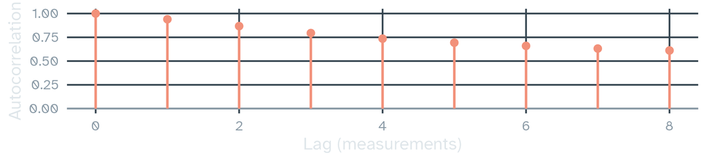

```r
ggplot(acf_gam, aes(x = lag, y = acf)) +
  geom_hline(yintercept = 0, colour = muted) +
  geom_segment(aes(xend = lag, yend = 0), colour = kingfisher, linewidth = 1.2) +
  geom_point(colour = kingfisher, size = 3) +
  labs(x = "Lag (measurements)", y = "Autocorrelation")
```

Neighbouring residuals correlate at about 0.94, and the correlation is still clearly positive several measurements apart.

# Random effects in GAMMs

`Did you know:` fruit bat pups raised without hearing adult bats kept producing underdeveloped, pup-like calls far into adolescence.

*Source: Prat, Taub & Yovel (2015), Science Advances*

## Three kinds of random effect

| `{mgcv}` term | Random effect |
| --- | --- |
| `s(speaker, bs = "re")` | random intercepts by speaker |
| `s(speaker, time, bs = "re")` | random slopes over time by speaker |
| `s(time, speaker, bs = "fs", m = 1)` | random smooths over time by speaker |

Watch the order: random slopes put the grouping factor first, random smooths put the continuous predictor first.

## Fitting the three

```r
m_int <- bam(f2 ~ l1_o + s(time, k = 10) + s(time, by = l1_o, k = 10) +
               s(speaker, bs = "re"),
             data = price, method = "ML")
m_slope <- bam(f2 ~ l1_o + s(time, k = 10) + s(time, by = l1_o, k = 10) +
                 s(speaker, bs = "re") + s(speaker, time, bs = "re"),
               data = price, method = "ML")
m_smooth <- bam(f2 ~ l1_o + s(time, k = 10) + s(time, by = l1_o, k = 10) +
                  s(time, speaker, bs = "fs", m = 1, k = 5),
                data = price, method = "ML")
```

## What each one allows

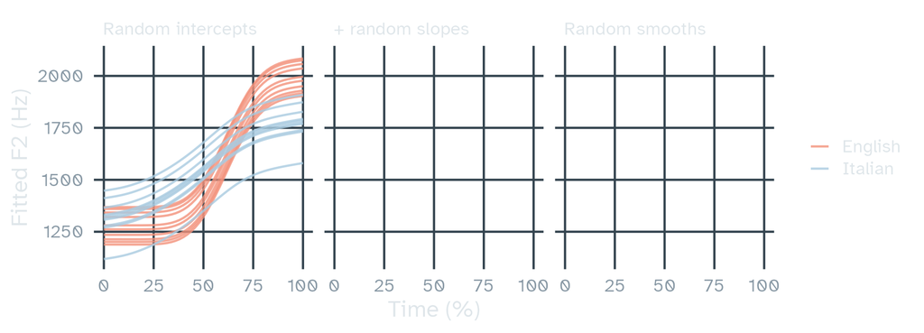

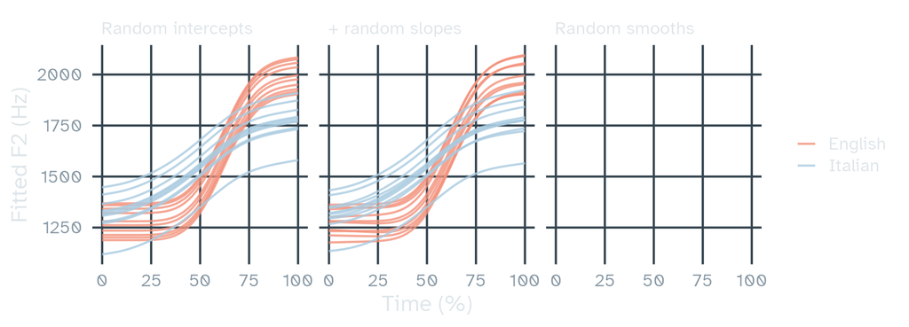

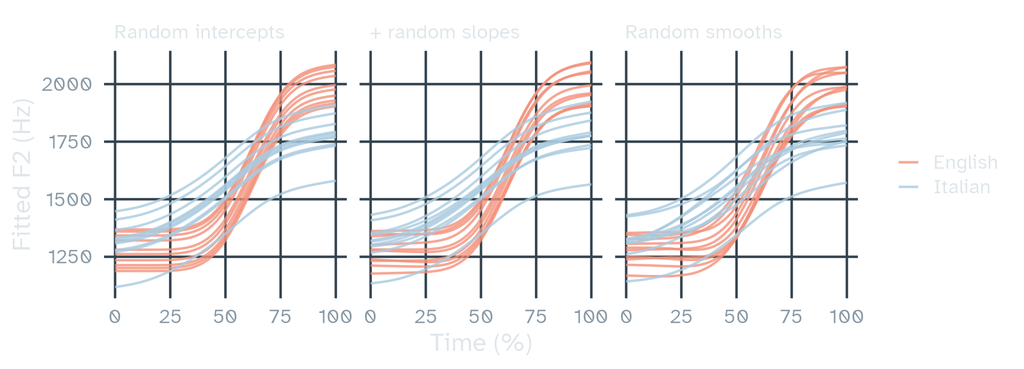

One line per speaker. Intercepts shift each speaker’s curve up or down, slopes tilt it, and random smooths let each speaker’s curve take its own shape.

## Random smooths

- `bs = "fs"` fits one smooth per speaker, with a shared smoothing parameter, much like random slopes share one variance
- `m = 1` changes the penalty so that each speaker’s smooth is pulled toward a flat line, as a random effect should be (Sóskuthy, 2017)
- `k` applies to each speaker: 20 speakers with `k = 5` add 100 coefficients. Keep `k` low; too many coefficients for the data stops the model with an error
- Many levels make random smooths slow and memory-hungry

## The random slope equivalent

- Our groups differ between speakers: each speaker is English or Italian, so the difference smooth cannot vary by speaker
- When a comparison is within speakers, say two vowels from every speaker, the model also needs speakers to differ in the vowel difference, like a by-speaker random slope in `lmer()`

One way is a random smooth for every speaker and vowel combination, `s(time, speaker_vowel, bs = "fs", m = 1)`. Sóskuthy (2021) compares this and other options in simulations.

# Autocorrelation

`Did you know:` isolated fruit bat pups that heard recordings of adult bats developed a repertoire that copied the playbacks.

*Source: Prat, Taub & Yovel (2015), Science Advances*

## Two solutions

Random smooths by speaker handle dependencies within speakers. For the dependencies within each trajectory, there are two options:

- Random smooths by trajectory, `s(time, traj, bs = "fs", m = 1)`, give each of the 200 tokens its own smooth
- An AR1 error model predicts the error at each measurement partly from the error at the previous one, with the correlation `rho`

## An AR1 model

```r
m_noar <- bam(f2 ~ l1_o + s(time, k = 10) + s(time, by = l1_o, k = 10) +
                s(time, speaker, bs = "fs", m = 1, k = 5),
              data = price, method = "ML")
rho <- itsadug::start_value_rho(m_noar)
m_ar <- bam(f2 ~ l1_o + s(time, k = 10) + s(time, by = l1_o, k = 10) +
              s(time, speaker, bs = "fs", m = 1, k = 5),
            data = price, method = "ML", AR.start = price$time == 0, rho = rho)
```

- `start_value_rho()` estimates `rho` from the lag-1 autocorrelation of a model without the AR1 component
- `AR.start` marks the first measurement of each trajectory, so the error model does not link one token to the next. The data must be sorted by trajectory and time

## Did it work?

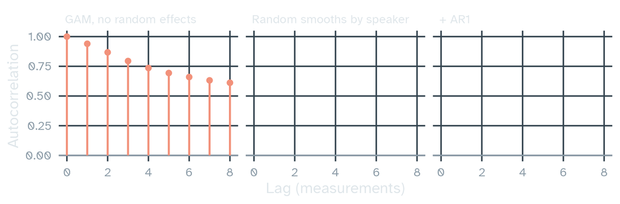

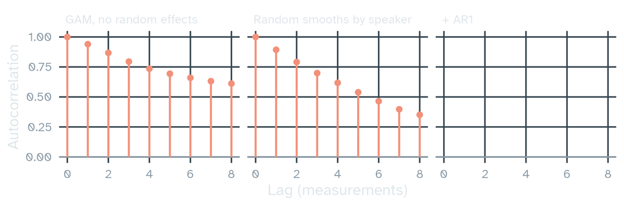

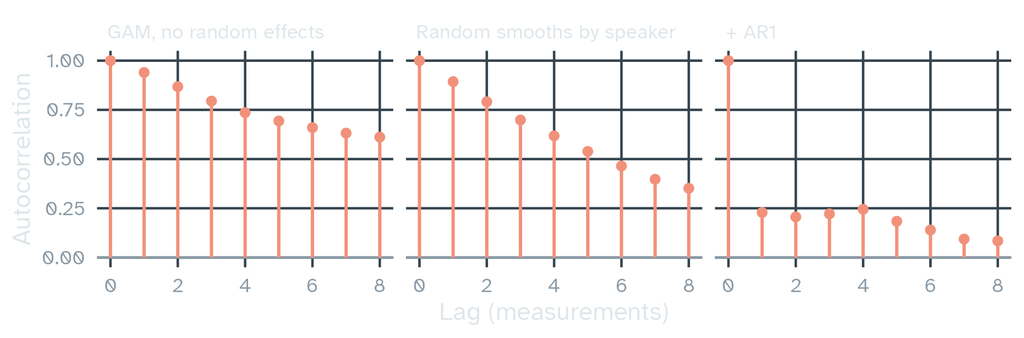

For the AR1 model, the autocorrelation is computed on the standardised residuals, `m_ar$std.rsd`, which take the error model into account.

## Random smooths or AR1?

- Random smooths by trajectory become very slow with many trajectories: Sóskuthy (2018) puts the practical limit at around 500 to 800
- AR1 adds almost no computing time, so for large data sets it is the only option
- An AR1 model may not remove all autocorrelation for some kinds of curves: always check the residuals
- `rho` is shared by all trajectories, and in `{mgcv}` the AR1 option is available in `bam()` only

# Non-linear interactions

`Did you know:` fruit bat pups raised in three groups, each hearing a different playback, developed distinct dialects from about six months of age, each closer to its own playback.

*Source: Prat, Azoulay, Dor & Yovel (2017), PLoS Biology*

## Duration and shape

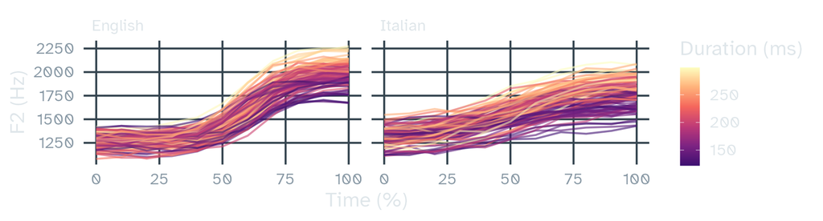

```r
ggplot(price, aes(x = time, y = f2, group = traj, colour = duration)) +
  geom_line(alpha = 0.6) +
  scale_colour_viridis_c(option = "magma", begin = 0.2) +
  facet_wrap(~ l1) +
  labs(x = "Time (%)", y = "F2 (Hz)", colour = "Duration (ms)") +
  theme(legend.position = "right")
```

Short vowels (dark) stop lower: the glide undershoots its target. Duration changes the shape of the curve as well as its height.

## `s()`, `te()` and `ti()`

- `s(duration)` adds a smooth effect of duration on overall F2: it can shift whole curves, but not change their shape
- `te(time, duration)` is a tensor product smooth: one surface over time and duration, including both main effects
- `ti(time, duration)` is the tensor product interaction alone. Combined with `s(time)` and `s(duration)`, it separates the main effects from the interaction, so each gets its own row in the summary

## The model

```r
m_dur <- bam(f2 ~ l1_o + s(time, k = 10) + s(time, by = l1_o, k = 10) +
               s(duration) + ti(time, duration) +
               s(time, speaker, bs = "fs", m = 1, k = 5),
             data = price, method = "ML", AR.start = price$time == 0, rho = rho)
round(summary(m_dur)$s.table, 2)
```

```
                      edf Ref.df      F p-value
s(time)              8.88   8.97 190.31       0
s(time):l1_oItalian  8.67   8.91  36.40       0
s(duration)          1.00   1.00 304.45       0
ti(time,duration)    4.51   5.17  83.45       0
s(time,speaker)     78.30  98.00  10.41       0
```

## Predictions at three durations

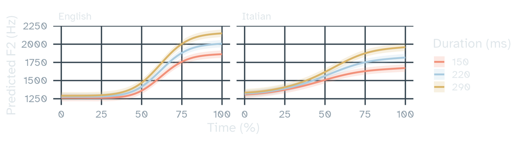

```r
predict_gam(m_dur, series = "time", length_out = 50,
            values = list(duration = c(150, 220, 290)),
            exclude_terms = "s(time,speaker)") |>
  ggplot(aes(x = time, y = f2, colour = factor(duration), fill = factor(duration))) +
  geom_ribbon(aes(ymin = lower_ci, ymax = upper_ci), alpha = 0.2, colour = NA) +
  geom_line(linewidth = 1.2) +
  facet_wrap(~ l1_o) +
  labs(x = "Time (%)", y = "Predicted F2 (Hz)", colour = "Duration (ms)", fill = "Duration (ms)") +
  theme(legend.position = "right")
```

`exclude_terms` removes the random smooths, so the curves are for an average speaker.

## The surface

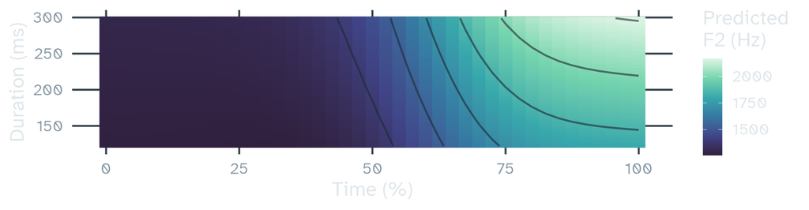

```r
predict_gam(m_dur, series = c("time", "duration"), length_out = 40,
            values = list(l1_o = "English"), exclude_terms = "s(time,speaker)") |>
  ggplot(aes(x = time, y = duration, fill = f2, z = f2)) +
  geom_raster() +
  geom_contour(colour = floor_col, alpha = 0.6, bins = 8) +
  scale_fill_viridis_c(option = "mako", begin = 0.15) +
  labs(x = "Time (%)", y = "Duration (ms)", fill = "Predicted\nF2 (Hz)") +
  theme(legend.position = "right")
```

A heat map shows the whole interaction for English speakers, but prediction curves at a few durations are easier to read.

# Checking and reporting

`Did you know:` the pups in the dialect experiment heard their mothers too, but their calls moved toward the playback of the whole colony. Prat and colleagues called this crowd vocal learning.

*Source: Prat, Azoulay, Dor & Yovel (2017), PLoS Biology*

## Checking the model

```r
k.check(m_dur)
```

```
                     k'       edf   k-index p-value
s(time)               9  8.880414 1.0565009  0.9950
s(time):l1_oItalian   9  8.669315 1.0565009  0.9975
s(duration)           9  1.001933 0.2914938  0.0000
ti(time,duration)    16  4.514466 1.0488305  0.9950
s(time,speaker)     100 78.296626 1.0565009  0.9975
```

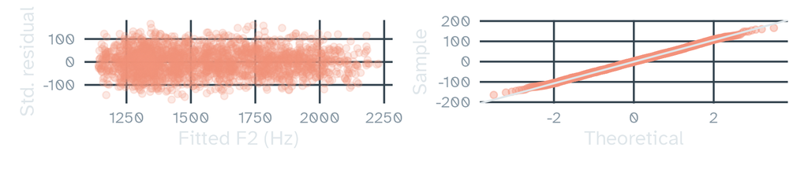

```r
p_resid <- ggplot(tibble(fitted = fitted(m_dur), res = m_dur$std.rsd), aes(fitted, res)) +
  geom_point(colour = kingfisher, alpha = 0.2) + labs(x = "Fitted F2 (Hz)", y = "Std. residual")
p_qq <- ggplot(tibble(res = m_dur$std.rsd), aes(sample = res)) +
  geom_qq(colour = kingfisher, alpha = 0.4) + geom_qq_line(colour = mist) + labs(x = "Theoretical", y = "Sample")
p_resid + p_qq
```

## Testing the group difference

```r
m_dur_null <- bam(f2 ~ s(time, k = 10) + s(duration) + ti(time, duration) +
                    s(time, speaker, bs = "fs", m = 1, k = 5),
                  data = price, method = "ML", AR.start = price$time == 0, rho = rho)
itsadug::compareML(m_dur_null, m_dur)
```

```
m_dur_null: f2 ~ s(time, k = 10) + s(duration) + ti(time, duration) + s(time,
    speaker, bs = "fs", m = 1, k = 5)

m_dur: f2 ~ l1_o + s(time, k = 10) + s(time, by = l1_o, k = 10) + s(duration) +
    ti(time, duration) + s(time, speaker, bs = "fs", m = 1, k = 5)

Chi-square test of ML scores
-----
       Model    Score Edf Difference    Df  p.value Sig.
1 m_dur_null 11087.91  10
2      m_dur 11035.71  13     52.200 3.000  < 2e-16  ***

AIC difference: 18.90, model m_dur has lower AIC.
```

Both models have the same random effects, error model and `rho`, and are fitted with `method = "ML"`.

## GAM versus GAMM

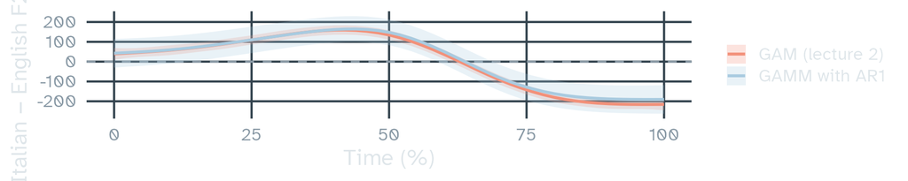

```r
compare <- list(l1_o = c("Italian", "English"))
bind_rows(`GAM (lecture 2)` = as_tibble(get_difference(m_gam, "time", compare, length_out = 50)),
          `GAMM with AR1` = as_tibble(get_difference(m_dur, "time", compare, length_out = 50,
                                                     exclude_terms = "s(time,speaker)")),
          .id = "model") |>
  ggplot(aes(x = time, y = diff, colour = model, fill = model)) +
  geom_hline(yintercept = 0, colour = muted, linetype = "dashed") +
  geom_ribbon(aes(ymin = lower_ci, ymax = upper_ci), alpha = 0.25, colour = NA) +
  geom_line(linewidth = 1.1) +
  labs(x = "Time (%)", y = "Italian − English F2 (Hz)", colour = NULL, fill = NULL) +
  theme(legend.position = "right")
```

The GAM treats the 2,200 measurements as independent; the GAMM knows they come from 200 tokens and 20 speakers.

## Summary

- Curve data have dependencies within trajectories and within speakers (and words); ignoring them makes intervals too narrow
- In `{mgcv}`, random intercepts and slopes use `bs = "re"`, and random smooths use `bs = "fs"` with `m = 1`
- An AR1 error model handles autocorrelation within trajectories cheaply; check the standardised residuals
- `ti()` adds a non-linear interaction between two continuous predictors; show it with prediction curves at a few values
- Test effects by comparing ML-fitted models with the same random effects and error model

## References

- Coretta, S. (2024). *tidygam: Tidy prediction and plotting of generalised additive models* (R package version 1.0.0). https://github.com/stefanocoretta/tidygam
- Sóskuthy, M. (2017). Generalised additive mixed models for dynamic analysis in linguistics: A practical introduction. *arXiv*, 1703.05339. https://arxiv.org/abs/1703.05339
- Sóskuthy, M. (2018). *Introducing generalised additive models* and *Becoming a GAM(M) warrior* [Workshop slides]. Analysing Curves, University of Manchester, 29 May 2018.
- Sóskuthy, M. (2021). Evaluating generalised additive mixed modelling strategies for dynamic speech analysis. *Journal of Phonetics*, 84, 101017. https://doi.org/10.1016/j.wocn.2020.101017
- Wieling, M. (2018). Analyzing dynamic phonetic data using generalized additive mixed modeling: A tutorial focusing on articulatory differences between L1 and L2 speakers of English. *Journal of Phonetics*, 70, 86–116. https://doi.org/10.1016/j.wocn.2018.03.002
- Wood, S. N. (2017). *Generalized additive models: An introduction with R* (2nd ed.). CRC Press. https://doi.org/10.1201/9781315370279

## Sources of the animal facts

- Prat, Y., Azoulay, L., Dor, R., & Yovel, Y. (2017). Crowd vocal learning induces vocal dialects in bats: Playback of conspecifics shapes fundamental frequency usage by pups. *PLoS Biology*, 15(10), e2002556. https://doi.org/10.1371/journal.pbio.2002556
- Prat, Y., Taub, M., & Yovel, Y. (2015). Vocal learning in a social mammal: Demonstrated by isolation and playback experiments in bats. *Science Advances*, 1(2), e1500019. https://doi.org/10.1126/sciadv.1500019
- Prat, Y., Taub, M., & Yovel, Y. (2016). Everyday bat vocalizations contain information about emitter, addressee, context, and behavior. *Scientific Reports*, 6, 39419. https://doi.org/10.1038/srep39419

## Slides and code

[figure not shown]

These slides

mcanzi.de/advanced_statistics/03_gamms.html

Code and all lectures

github.com/mcanzi/advanced_statistics